# Machine Learning 1

Alex Osterbuhr

2023-03-23

```r
library(tidyverse)
library(stringr)
library(lubridate)
library(ggplot2)
library(stringr)
```

## PART I: Collect and Describe the Data

### Problem 1

##### Import the data and call it inspections. Assign the directed names (and data types) to the columns. Make sure to use the tidyverse package as much as possible. This includes making use of the read_csv() functions when importing data. Use the glimpse() function to show that your data was imported properly.

```r
inspections <- read_csv('https://s3.amazonaws.com/notredame.analytics.data/inspections.csv', col_types = 'icccffcfff?ffcddc')

inspections <- inspections %>%
  rename(ID = `Inspection ID`, DBAName = `DBA Name`, AKAName = `AKA Name`, License = `License #`, FacilityType = `Facility Type`, InspectionDate = `Inspection Date`, InspectionType = `Inspection Type`, ZIP = `Zip`) %>%
  mutate(InspectionDate = as.Date(InspectionDate, format = '%m/%d/%Y'))

glimpse(inspections)
```

```
## Rows: 140,954
## Columns: 17
## $ ID             <int> 1995829, 1995817, 1995822, 1995814, 1995811, 1995752, 1…
## $ DBAName        <chr> "SUBWAY", "VENEZUELAN BOWL GRILL LLC", "SEVEN TEN", "CH…
## $ AKAName        <chr> "SUBWAY", "VENEZUELAN BOWL GRILL", "SEVEN TEN", "CHISME…
## $ License        <chr> "1679112", "2424110", "1172093", "1334960", "2334190", …
## $ FacilityType   <fct> "Restaurant", "Restaurant", "Restaurant", "Restaurant",…
## $ Risk           <fct> Risk 1 (High), Risk 1 (High), Risk 1 (High), Risk 1 (Hi…
## $ Address        <chr> "8711 S ASHLAND AVE", "2436 N LINCOLN AVE", "1055 E 55T…
## $ City           <fct> CHICAGO, CHICAGO, CHICAGO, CHICAGO, CHICAGO, CHICAGO, C…
## $ State          <fct> IL, IL, IL, IL, IL, IL, IL, IL, IL, IL, IL, IL, IL, IL,…
## $ ZIP            <fct> 60620, 60614, 60615, 60629, 60615, 60621, 60630, 60614,…
## $ InspectionDate <date> 2017-03-17, 2017-03-17, 2017-03-17, 2017-03-17, 2017-0…
## $ InspectionType <fct> Canvass Re-Inspection, Canvass Re-Inspection, Canvass R…
## $ Results        <fct> Pass, Pass, Pass, Pass, Pass, Pass, Out of Business, Pa…
## $ Violations     <chr> "19. OUTSIDE GARBAGE WASTE GREASE AND STORAGE AREA; CLE…
## $ Latitude       <dbl> 41.73541, 41.92619, 41.79492, 41.78429, 41.79517, 41.77…
## $ Longitude      <dbl> -87.66291, -87.65002, -87.59985, -87.72277, -87.59710, …
## $ Location       <chr> "(41.735408702583165, -87.66290968424336)", "(41.926190…
```

Inspections data brought in, columns renamed and column types changed per assignment instructions.

### Problem 2

##### Show summary statistics for the City, State, ZIP, InspectionDate, Longitude, and Latitude features only.

```r
inspections %>%
  select(City, State, ZIP, InspectionDate, Longitude, Latitude) %>%
  mutate(InspectionDate = as.Date(InspectionDate, format = '%m/%d/%y')) %>%
  summary()
```

```
##        City         State             ZIP         InspectionDate
##  CHICAGO :140390   IL  :140946   60614  :  5266   Min.   :2010-01-04
##  Chicago :   244   NA's:     8   60647  :  4874   1st Qu.:2011-12-28
##  chicago :    75                 60657  :  4748   Median :2013-11-08
##  CCHICAGO:    37                 60611  :  4577   Mean   :2013-10-10
##  MAYWOOD :    12                 60622  :  4549   3rd Qu.:2015-08-11
##  (Other) :   147                 (Other):116934   Max.   :2017-03-17
##  NA's    :    49                 NA's   :     6
##    Longitude         Latitude
##  Min.   :-87.91   Min.   :41.64
##  1st Qu.:-87.71   1st Qu.:41.83
##  Median :-87.67   Median :41.89
##  Mean   :-87.68   Mean   :41.88
##  3rd Qu.:-87.63   3rd Qu.:41.94
##  Max.   :-87.53   Max.   :42.02
##  NA's   :494      NA's   :494
```

## PART II: Resolve Data Quality Issues

##### As we discussed in class, resolving data quality issues is a significant part of the analytics process. The quality of a machine learning model is heavily dependent on the quality of the data that was used to train it.

### Problem 1

##### Upon close inspection, we notice that one of the zip code values is “60627”. This is incorrect. It should be “60827”. Fix this.

```r
inspections<- inspections %>%
  mutate(ZIP = recode_factor(ZIP, '60627' = '60827'))

inspections %>% filter(ZIP== '60627')
```

```
## # A tibble: 0 × 17
## # … with 17 variables: ID <int>, DBAName <chr>, AKAName <chr>, License <chr>,
## #   FacilityType <fct>, Risk <fct>, Address <chr>, City <fct>, State <fct>,
## #   ZIP <fct>, InspectionDate <date>, InspectionType <fct>, Results <fct>,
## #   Violations <chr>, Latitude <dbl>, Longitude <dbl>, Location <chr>
```

All instances where ZIP is 60627 changed to 60827. Last bit of code shows there are no more instances where ZIP is 60627.

### Problem 2

##### We also notice that a business called “STEVES 77 ICE CREAM” has no zip code and is listed in the city of “BRIDEVIEW”. There is no city in Illinois with this name. The city should be “Bridgeview”, with a zip code of “60455”. Fix this

```r
levels(inspections$ZIP) <-  c(levels(inspections$ZIP),"60455")
levels(inspections$City) <-  c(levels(inspections$City),"BRIDGEVIEW")

inspections <- inspections %>%
  mutate(ZIP = replace(ZIP, DBAName == 'STEVES 77 ICE CREAM', '60455'),
         City = replace(City, DBAName == 'STEVES 77 ICE CREAM', 'BRIDGEVIEW'),
         City = replace(City, City == 'BRIDEVIEW', 'BRIDGEVIEW'),
         ZIP = replace(ZIP, ((City == 'BRIDGEVIEW') & (ZIP == is.na(ZIP))), '60455'))

inspections %>% filter(DBAName=='STEVES 77 ICE CREAM')
```

```
## # A tibble: 1 × 17
##        ID DBAName        AKAName License Facil…¹ Risk  Address City  State ZIP
##     <int> <chr>          <chr>   <chr>   <fct>   <fct> <chr>   <fct> <fct> <fct>
## 1 1734651 STEVES 77 ICE… STEVES… 2451367 Mobile… Risk… 7451 W… BRID… IL    60455
## # … with 7 more variables: InspectionDate <date>, InspectionType <fct>,
## #   Results <fct>, Violations <chr>, Latitude <dbl>, Longitude <dbl>,
## #   Location <chr>, and abbreviated variable name ¹FacilityType
```

Originally received message where level ‘60455’ and ‘Bridgeview’ were not found. First two lines create these levels in the applicable features. Next set of code mutates the accidental or missing information per assignment instructions. Last line shows that the code changed this information.

### Problem 3

##### Besides STEVES 77 ICE CREAM, there are two other businesses with missing zip codes. To resolve these, let’s assume that businesses on the same street or that are in close proximity to each other share the same zip code. Use this information to resolve the missing zip codes for the remaining two businesses.

```r
inspections %>%
  filter(is.na(ZIP)) %>%
  distinct(DBAName,Address,ZIP)
```

```
## # A tibble: 2 × 3
##   DBAName       Address           ZIP
##   <chr>         <chr>             <fct>
## 1 Chartwells    2324 N FREMONT ST <NA>
## 2 DUNKIN DONUTS 7545 N PAULINA ST <NA>
```

```r
inspections %>%
  filter(grepl('FREMONT|PAULINA', Address)) %>%
  distinct(DBAName, Address, ZIP)
```

```
## # A tibble: 30 × 3
##    DBAName                             Address                ZIP
##    <chr>                               <chr>                  <fct>
##  1 PETE'S GRILL                        7557 N PAULINA ST      60626
##  2 MILES DAVIS MAGNET ELEMENTARY       6740 S PAULINA         60636
##  3 SUBWAY SANDWICHES                   7549-7551 N PAULINA ST 60626
##  4 FRASCA                              3356-3358 N PAULINA    60657
##  5 REDZ BELIZEAN RESTAURANT LLC        7605 N PAULINA ST      60626
##  6 PIZZERIA BEBU                       1521 N FREMONT ST      60642
##  7 A JUST HARVEST                      7649 N PAULINA ST      60626
##  8 Chartwells                          2324 N FREMONT ST      <NA>
##  9 SODEXHO AMERICA, LLC                3737 S PAULINA ST      60609
## 10 PEACE & ED COALITION  (BIG PICTURE) 4946 S PAULINA ST      60609
## # … with 20 more rows
```

```r
inspections <- inspections %>%
  mutate(ZIP=replace(ZIP, (DBAName=='DUNKIN DONUTS' & is.na(ZIP)),'60626'),
         ZIP=replace(ZIP, (DBAName=='Chartwells' & is.na(ZIP)), '60642'))

inspections %>%
 filter(is.na(ZIP))
```

```
## # A tibble: 0 × 17
## # … with 17 variables: ID <int>, DBAName <chr>, AKAName <chr>, License <chr>,
## #   FacilityType <fct>, Risk <fct>, Address <chr>, City <fct>, State <fct>,
## #   ZIP <fct>, InspectionDate <date>, InspectionType <fct>, Results <fct>,
## #   Violations <chr>, Latitude <dbl>, Longitude <dbl>, Location <chr>
```

First filtered inspections to see which two restaurants had an NA value in ZIP and wanted to view the Address as well for the street name. Next, we filtered the Address feature for those two street street names and showed ZIP to next assign similar ZIP to the two remaining restaurants missing ZIP according to street address. Note, direction of street address is taken into account here as well as S or N shows different ZIP values in those cases.

### Problem 4

##### The summary statistics we ran in a previous step showed that not only is our dataset missing values for the City, State, Longitude, and Latitude features, but some of the city names are also inconsistently spelled or misspelled. For example, the city of Chicago is listed as “CHICAGO”, “Chicago”, “CCHICAGO”, etc. To resolve these data quality issues, make use of a reference dataset as a source of truth. Import a reference zip code data set from “https://s3.amazonaws.com/notredame.analytics.data/zipcode.csv”. Use the glimpse() function to show that your data was imported properly.

```r
zipcode <- read_csv('https://s3.amazonaws.com/notredame.analytics.data/zipcode.csv', col_types = 'fffdd')

glimpse(zipcode)
```

```
## Rows: 44,336
## Columns: 5
## $ zip       <fct> 00210, 00211, 00212, 00213, 00214, 00215, 00501, 00544, 0060…
## $ city      <fct> Portsmouth, Portsmouth, Portsmouth, Portsmouth, Portsmouth, …
## $ state     <fct> NH, NH, NH, NH, NH, NH, NY, NY, PR, PR, PR, PR, PR, PR, PR, …
## $ latitude  <dbl> 43.00590, 43.00590, 43.00590, 43.00590, 43.00590, 43.00590, …
## $ longitude <dbl> -71.01320, -71.01320, -71.01320, -71.01320, -71.01320, -71.0…
```

```r
zipcode <- zipcode %>%
  rename(ZIP = `zip`, City = `city`, State = `state`, Latitude = `latitude`,  Longitude = `longitude`)
```

Zipcode data brought in and column names/ types changed to align with inspection data.

### Problem 5

##### The reference dataset contains the city, state, latitude, and longitude data for most U.S. zip codes. It is sourced from the Civic Space Database. Use this dataset to resolve the inconsistent city names as well as the missing values for the City, State, Longitude, and Latitude features. It is safe to assume that all non-missing zip codes in the inspections dataset are accurate and that you can replace the city names in the inspections dataset with those from the reference dataset. Hint: A join would be useful here.

```r
inspections <- left_join(inspections, zipcode, by='ZIP') %>%
  mutate(City = City.y, State = State.y,
         Latitude =if_else(is.na(Latitude.x) & !is.na(Latitude.y), Latitude.y, Latitude.x),
         Longitude = if_else(is.na(Longitude.x) & !is.na(Longitude.y), Longitude.y, Longitude.x)) %>%
  select(-City.x,-City.y,-State.x,-State.y,-Longitude.x,-Longitude.y,-Latitude.x,-Latitude.y)
```

Joined inspection data and zipcode data on ZIP as there are no NA values there and it is the most distinctly comparable feature (ie City can align with multiple ZIP values and there are NA values in Longitude and Latitude). Changed City and State to align with the values of those in zipcode dataset. Also told Longitude and Latitude to remain unless it was an NA value. If it is an NA value it takes what is in the zipcode set. Finally, removed the features of City, State, Longitude, and Latitude that were from inspections and zipcode since the new features are our true features.

### Problem 6

##### Show summary statistics for the City, State, ZIP, Longitude, and Latitude features only. Note that the City, State, and ZIP features must be factors

```r
inspections %>%
  select(City, State, ZIP, Longitude, Latitude) %>%
  summary()
```

```
##                 City            State             ZIP           Longitude
##  Chicago          :138218   IL     :140954   60614  :  5266   Min.   :-88.18
##  Amf Ohare        :  1739   NH     :     0   60647  :  4874   1st Qu.:-87.71
##  Elmwood Park     :   782   NY     :     0   60657  :  4748   Median :-87.67
##  Riverdale        :   103   PR     :     0   60611  :  4577   Mean   :-87.68
##  Maywood          :    13   VI     :     0   60622  :  4549   3rd Qu.:-87.63
##  Elk Grove Village:    10   MA     :     0   60618  :  4258   Max.   :-87.53
##  (Other)          :    89   (Other):     0   (Other):112682
##     Latitude
##  Min.   :41.50
##  1st Qu.:41.82
##  Median :41.89
##  Mean   :41.88
##  3rd Qu.:41.94
##  Max.   :42.20
##
```

## PART III: Visualize and Interpret the Data

### Problem 1

##### An inspection of the Violations feature shows that the description for each inspection violation is separated by a pipe character (“|”). With this knowledge, create a new feature called ViolationCount that represents the number of violations from each inspection. Remember that missing data can have meaning. Hint: The str_count() function from the stringr package would be useful here. For example, to find the number of occurrences of the character “%” in a string called x, we run str_count(x,“\%”).

```r
inspections <- inspections %>%
  mutate(ViolationCount = str_count(Violations, '\\|') +1,
         ViolationCount = ifelse(is.na(Violations), 0, ViolationCount))

inspections %>% filter(is.na(ViolationCount))
```

```
## # A tibble: 0 × 18
## # … with 18 variables: ID <int>, DBAName <chr>, AKAName <chr>, License <chr>,
## #   FacilityType <fct>, Risk <fct>, Address <chr>, ZIP <fct>,
## #   InspectionDate <date>, InspectionType <fct>, Results <fct>,
## #   Violations <chr>, Location <chr>, City <fct>, State <fct>, Latitude <dbl>,
## #   Longitude <dbl>, ViolationCount <dbl>
```

##### Create the appropriate chart that illustrates the relationship between the number of inspection violations and the inspection results for “Pass”, “Fail” and “Pass w/ Conditions”. Hint: Note that for this question, we are comparing discrete values against continuous values

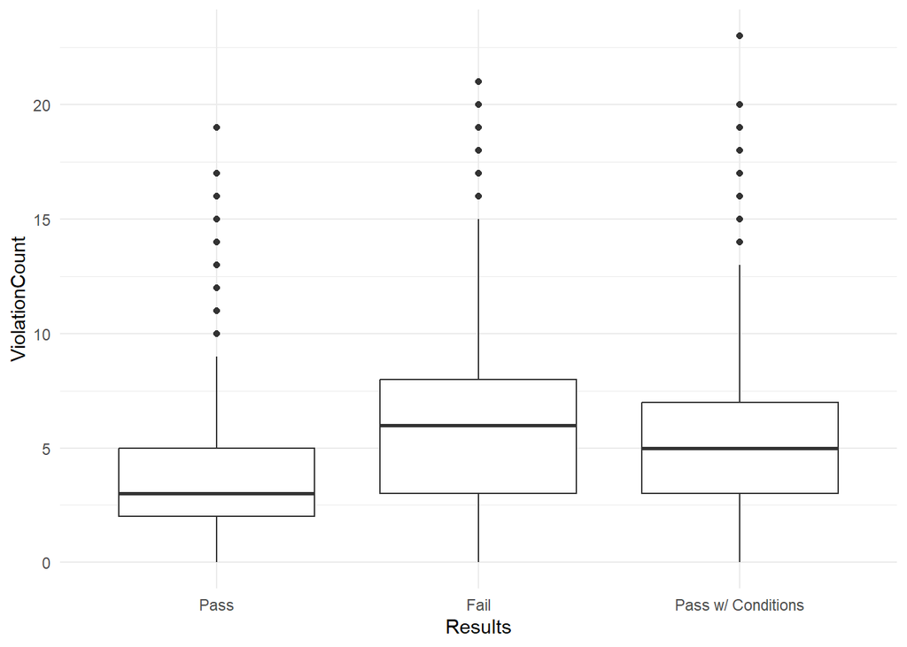

```r
inspections %>%
  filter(Results=='Pass'| Results=='Fail'| Results=='Pass w/ Conditions') %>%
  ggplot(aes(Results, ViolationCount)) +
  geom_boxplot()+
  theme_minimal()
```

Filtered down to Pass, Fail, and Pass w/ Conditions in Results feature. Then charted those against ViolationsCount feature that was created using a boxplot since comparing discrete and continuous values.

### Problem 3

##### Based on the chart, describe the relationship between the inspection results and the number of violations

Looking at this chart, we see that locations that pass have the least amount of violations and those that fail have the most. Since this is a restaurant inspection data set, thankfully this is true as it was to be expected. What is interesting is that those restaurants that pass with conditions have violation counts that closer reflect those that fail than those that pass.